# Tibbles: Solutions

```r
require(tidyverse)
```

1. How can you tell if an object is a tibble? (Hint: try printing mtcars, which is a regular data frame).

When we print mtcars, it prints all the columns.

```r
mtcars
```

```
##                      mpg cyl  disp  hp drat    wt  qsec vs am gear carb
## Mazda RX4           21.0   6 160.0 110 3.90 2.620 16.46  0  1    4    4
## Mazda RX4 Wag       21.0   6 160.0 110 3.90 2.875 17.02  0  1    4    4
## Datsun 710          22.8   4 108.0  93 3.85 2.320 18.61  1  1    4    1
## Hornet 4 Drive      21.4   6 258.0 110 3.08 3.215 19.44  1  0    3    1
## Hornet Sportabout   18.7   8 360.0 175 3.15 3.440 17.02  0  0    3    2
## Valiant             18.1   6 225.0 105 2.76 3.460 20.22  1  0    3    1
## Duster 360          14.3   8 360.0 245 3.21 3.570 15.84  0  0    3    4
## Merc 240D           24.4   4 146.7  62 3.69 3.190 20.00  1  0    4    2
## Merc 230            22.8   4 140.8  95 3.92 3.150 22.90  1  0    4    2
## Merc 280            19.2   6 167.6 123 3.92 3.440 18.30  1  0    4    4
## Merc 280C           17.8   6 167.6 123 3.92 3.440 18.90  1  0    4    4
## Merc 450SE          16.4   8 275.8 180 3.07 4.070 17.40  0  0    3    3
## Merc 450SL          17.3   8 275.8 180 3.07 3.730 17.60  0  0    3    3
## Merc 450SLC         15.2   8 275.8 180 3.07 3.780 18.00  0  0    3    3
## Cadillac Fleetwood  10.4   8 472.0 205 2.93 5.250 17.98  0  0    3    4
## Lincoln Continental 10.4   8 460.0 215 3.00 5.424 17.82  0  0    3    4
## Chrysler Imperial   14.7   8 440.0 230 3.23 5.345 17.42  0  0    3    4
## Fiat 128            32.4   4  78.7  66 4.08 2.200 19.47  1  1    4    1
## Honda Civic         30.4   4  75.7  52 4.93 1.615 18.52  1  1    4    2
## Toyota Corolla      33.9   4  71.1  65 4.22 1.835 19.90  1  1    4    1
## Toyota Corona       21.5   4 120.1  97 3.70 2.465 20.01  1  0    3    1
## Dodge Challenger    15.5   8 318.0 150 2.76 3.520 16.87  0  0    3    2
## AMC Javelin         15.2   8 304.0 150 3.15 3.435 17.30  0  0    3    2
## Camaro Z28          13.3   8 350.0 245 3.73 3.840 15.41  0  0    3    4
## Pontiac Firebird    19.2   8 400.0 175 3.08 3.845 17.05  0  0    3    2
## Fiat X1-9           27.3   4  79.0  66 4.08 1.935 18.90  1  1    4    1
## Porsche 914-2       26.0   4 120.3  91 4.43 2.140 16.70  0  1    5    2
## Lotus Europa        30.4   4  95.1 113 3.77 1.513 16.90  1  1    5    2
## Ford Pantera L      15.8   8 351.0 264 4.22 3.170 14.50  0  1    5    4
## Ferrari Dino        19.7   6 145.0 175 3.62 2.770 15.50  0  1    5    6
## Maserati Bora       15.0   8 301.0 335 3.54 3.570 14.60  0  1    5    8
## Volvo 142E          21.4   4 121.0 109 4.11 2.780 18.60  1  1    4    2
```

But when we first convert `mtcars` to a tibble using `as_tibble()`, it prints only the first ten observations. There are also some other differences in formatting of the printed data frame. It prints the number of rows and columns and the date type of each column.

```r
as_tibble(mtcars)
```

```
## # A tibble: 32 × 11
##      mpg   cyl  disp    hp  drat    wt  qsec    vs    am  gear  carb
##    <dbl> <dbl> <dbl> <dbl> <dbl> <dbl> <dbl> <dbl> <dbl> <dbl> <dbl>
##  1  21       6  160    110  3.9   2.62  16.5     0     1     4     4
##  2  21       6  160    110  3.9   2.88  17.0     0     1     4     4
##  3  22.8     4  108     93  3.85  2.32  18.6     1     1     4     1
##  4  21.4     6  258    110  3.08  3.22  19.4     1     0     3     1
##  5  18.7     8  360    175  3.15  3.44  17.0     0     0     3     2
##  6  18.1     6  225    105  2.76  3.46  20.2     1     0     3     1
##  7  14.3     8  360    245  3.21  3.57  15.8     0     0     3     4
##  8  24.4     4  147.    62  3.69  3.19  20       1     0     4     2
##  9  22.8     4  141.    95  3.92  3.15  22.9     1     0     4     2
## 10  19.2     6  168.   123  3.92  3.44  18.3     1     0     4     4
## # … with 22 more rows
```

You can use the function is_tibble() to check whether a data frame is a tibble or not. The mtcars data frame is not a tibble.

```r
is_tibble(mtcars)
```

```
## [1] FALSE
```

More generally, you can use the class() function to find out the class of an object. Tibbles has the classes c(“tbl_df”, “tbl”, “data.frame”), while old data frames will only have the class “data.frame”.

```r
class(mtcars)
```

```
## [1] "data.frame"
```

2. Practice referring to non-syntactic names in the following data frame by:

```r
annoying <- tibble(
  `1` = 1:10,
  `2` = `1` * 2 + rnorm(length(`1`))
)
```

- Extracting the variable called 1.

```r
annoying[["1"]]
```

```
##  [1]  1  2  3  4  5  6  7  8  9 10
```

or

```r
annoying$`1`
```

```
##  [1]  1  2  3  4  5  6  7  8  9 10
```

- Plotting a scatterplot of 1 vs 2.

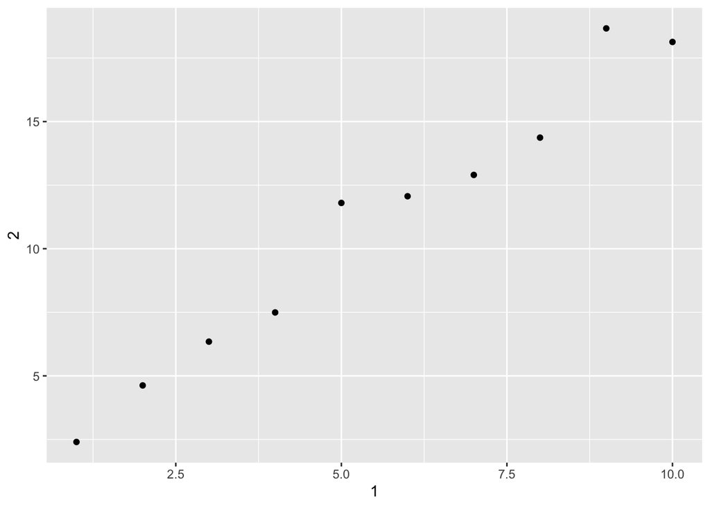

```r
ggplot(annoying, aes(x = `1`, y = `2`)) +
  geom_point()
```

- Creating a new column called 3 which is 2 divided by 1.

```r
annoying <- mutate(annoying, `3` = `2` / `1`)
annoying
```

```
## # A tibble: 10 × 3
##      `1`   `2`   `3`
##    <int> <dbl> <dbl>
##  1     1  2.40  2.40
##  2     2  4.62  2.31
##  3     3  6.35  2.12
##  4     4  7.49  1.87
##  5     5 11.8   2.36
##  6     6 12.1   2.01
##  7     7 12.9   1.84
##  8     8 14.4   1.80
##  9     9 18.7   2.07
## 10    10 18.1   1.81
```

- Renaming the columns to one, two and three.

```r
annoying <- rename(annoying, one = `1`, two = `2`, three = `3`)
glimpse(annoying)
```

```
## Rows: 10
## Columns: 3
## $ one   <int> 1, 2, 3, 4, 5, 6, 7, 8, 9, 10
## $ two   <dbl> 2.400988, 4.624643, 6.346024, 7.494190, 11.800780, 12.064111, 12…
## $ three <dbl> 2.400988, 2.312322, 2.115341, 1.873548, 2.360156, 2.010685, 1.84…
```

3. What option controls how many additional column names are printed at the footer of a tibble?

The help page for the `print()` method of tibble objects is discussed in `?print.tbl`. The `max_extra_cols` argument determines the number of extra columns to print information for.